# K-means Clustering

Yunting Chiu

2021-06-05

# Palmer Station Penguin Data

We will be using the [palmerpenguins](https://allisonhorst.github.io/palmerpenguins/) data set for this lab.

We will also be needing to load the [broom](https://broom.tidymodels.org/) package

```r
library(palmerpenguins)
library(broom)
library(tidymodels)
library(tidyverse)
# our data set
head(penguins)
```

```
## # A tibble: 6 x 8
##   species island bill_length_mm bill_depth_mm flipper_length_… body_mass_g sex
##   <fct>   <fct>           <dbl>         <dbl>            <int>       <int> <fct>
## 1 Adelie  Torge…           39.1          18.7              181        3750 male
## 2 Adelie  Torge…           39.5          17.4              186        3800 fema…
## 3 Adelie  Torge…           40.3          18                195        3250 fema…
## 4 Adelie  Torge…           NA            NA                 NA          NA <NA>
## 5 Adelie  Torge…           36.7          19.3              193        3450 fema…
## 6 Adelie  Torge…           39.3          20.6              190        3650 male
## # … with 1 more variable: year <int>
```

1. Transform the data set into a matrix using two of the numeric variables

```r
# tidyverse style
penguins %>%
  select(bill_length_mm, bill_depth_mm) %>%
  drop_na() %>%
  as.matrix() -> pen2
pen2 %>%
  nrow() # the matrix has 342 observations
```

```
## [1] 342
```

```r
# Base R style
penn <- as.matrix(penguins[, c("bill_length_mm", "bill_depth_mm")])
```

# 3 Clusters

```r
set.seed(1234)
pen2_kmeans <- kmeans(pen2, centers = 3) # perform k-means clustering on a data matrix
pen2_kmeans
```

```
## K-means clustering with 3 clusters of sizes 85, 116, 141
##
## Cluster means:
##   bill_length_mm bill_depth_mm
## 1       50.90353      17.33647
## 2       45.51379      15.64397
## 3       38.40355      18.27943
##
## Clustering vector:
##   [1] 3 3 3 3 3 3 3 3 3 3 3 3 3 3 3 3 3 3 2 3 3 3 3 3 3 3 3 3 3 3 3 3 3 3 3 3 3
##  [38] 3 3 3 3 3 2 3 3 3 3 3 3 3 3 3 3 3 3 3 3 3 3 3 3 3 3 3 3 3 3 3 3 3 3 3 2 3
##  [75] 2 3 3 3 3 3 2 3 3 3 3 3 3 3 3 3 3 3 3 3 3 3 3 3 2 3 3 3 3 3 3 3 3 3 2 3 2
## [112] 3 3 3 2 3 3 3 3 3 3 3 3 3 3 3 3 3 2 3 2 3 3 3 3 3 3 3 3 3 3 3 3 3 3 3 3 3
## [149] 3 3 3 2 1 2 1 2 2 2 2 2 2 2 1 2 2 2 1 2 1 2 1 1 2 2 2 2 2 2 2 2 1 2 2 2 1
## [186] 1 1 2 2 2 1 2 1 2 1 1 2 2 1 2 2 2 2 2 1 2 2 2 2 2 1 2 2 2 1 2 1 2 1 2 1 2
## [223] 2 2 2 2 1 2 1 2 2 1 1 2 1 2 1 2 1 2 1 2 1 2 1 2 1 1 2 2 1 2 1 2 1 2 2 2 1
## [260] 2 2 1 1 2 1 2 1 2 1 2 2 1 2 1 2 1 1 2 1 2 2 1 2 1 2 1 2 1 2 1 1 1 2 1 2 1
## [297] 2 1 2 1 1 1 2 1 3 1 2 1 1 2 2 1 2 1 1 2 1 2 1 1 1 1 1 1 2 1 2 1 2 1 2 1 1
## [334] 2 1 2 2 1 2 1 1 1
##
## Within cluster sum of squares by cluster:
## [1] 617.9859 754.7437 944.4986
##  (between_SS / total_SS =  79.8 %)
##
## Available components:
##
## [1] "cluster"      "centers"      "totss"        "withinss"     "tot.withinss"
## [6] "betweenss"    "size"         "iter"         "ifault"
```

3. Look at the result object with `summary()`, `names()`, and `str()`.
- The `summary()` shows the elements in `pen2_kmeans`.

```r
summary(pen2_kmeans)
```

```
##              Length Class  Mode
## cluster      342    -none- numeric
## centers        6    -none- numeric
## totss          1    -none- numeric
## withinss       3    -none- numeric
## tot.withinss   1    -none- numeric
## betweenss      1    -none- numeric
## size           3    -none- numeric
## iter           1    -none- numeric
## ifault         1    -none- numeric
```

We also can found the attributes by using `names()`.

- `cluster`: A vector of integers (from 1:k) indicating the cluster to which each point is allocated.
- `centers`: A matrix of cluster centers
- `totss`: The total sum of squares.
- `withinss`: Vector of within-cluster sum of squares, one component per cluster.
- `tot.withinss`: Total within-cluster sum of squares, i.e.`sum(withinss)`.
- `betweenss`: The between-cluster sum of squares, i.e.`totss-tot.withinss`.
- `size`: The number of points in each cluster (observations).
- `iter`: The number of (outer) iterations.
- `ifault`: integer: indicator of a possible algorithm problem – for experts.

```r
names(pen2_kmeans) # between within sum of square
```

```
## [1] "cluster"      "centers"      "totss"        "withinss"     "tot.withinss"
## [6] "betweenss"    "size"         "iter"         "ifault"
```

For example, I want to see how many iterations in `pen2_kmeans`, I will carry out:

```r
pen2_kmeans$iter
```

```
## [1] 2
```

`str()` displays the specific structure of an object.

```r
str(pen2_kmeans)
```

```
## List of 9
##  $ cluster     : int [1:342] 3 3 3 3 3 3 3 3 3 3 ...
##  $ centers     : num [1:3, 1:2] 50.9 45.5 38.4 17.3 15.6 ...
##   ..- attr(*, "dimnames")=List of 2
##   .. ..$ : chr [1:3] "1" "2" "3"
##   .. ..$ : chr [1:2] "bill_length_mm" "bill_depth_mm"
##  $ totss       : num 11494
##  $ withinss    : num [1:3] 618 755 944
##  $ tot.withinss: num 2317
##  $ betweenss   : num 9177
##  $ size        : int [1:3] 85 116 141
##  $ iter        : int 2
##  $ ifault      : int 0
##  - attr(*, "class")= chr "kmeans"
```

4. Use `augment()`, `glance()` and `tidy()` to extract information from the model
- `tidy()` generates a readable output.

```r
tidy(pen2_kmeans)
```

```
## # A tibble: 3 x 5
##   bill_length_mm bill_depth_mm  size withinss cluster
##            <dbl>         <dbl> <int>    <dbl> <fct>
## 1           50.9          17.3    85     618. 1
## 2           45.5          15.6   116     755. 2
## 3           38.4          18.3   141     944. 3
```

`glance()` shows the simple over view of the model.

```r
glance(pen2_kmeans)
```

```
## # A tibble: 1 x 4
##    totss tot.withinss betweenss  iter
##    <dbl>        <dbl>     <dbl> <int>
## 1 11494.        2317.     9177.     2
```

`augment()` saves the results in the existing data set, automatically generating a new column.

```r
augment(pen2_kmeans, data = pen2)
```

```
## # A tibble: 342 x 3
##    bill_length_mm bill_depth_mm .cluster
##             <dbl>         <dbl> <fct>
##  1           39.1          18.7 3
##  2           39.5          17.4 3
##  3           40.3          18   3
##  4           36.7          19.3 3
##  5           39.3          20.6 3
##  6           38.9          17.8 3
##  7           39.2          19.6 3
##  8           34.1          18.1 3
##  9           42            20.2 3
## 10           37.8          17.1 3
## # … with 332 more rows
```

Or we can select more variables from the original data and attach the results as a new data set.

```r
penguins %>%
  select(species, island, year, bill_length_mm, bill_depth_mm) %>%
  drop_na() -> new_penguins
augment(pen2_kmeans, data = new_penguins) -> new_clusters
head(new_clusters)
```

```
## # A tibble: 6 x 6
##   species island     year bill_length_mm bill_depth_mm .cluster
##   <fct>   <fct>     <int>          <dbl>         <dbl> <fct>
## 1 Adelie  Torgersen  2007           39.1          18.7 3
## 2 Adelie  Torgersen  2007           39.5          17.4 3
## 3 Adelie  Torgersen  2007           40.3          18   3
## 4 Adelie  Torgersen  2007           36.7          19.3 3
## 5 Adelie  Torgersen  2007           39.3          20.6 3
## 6 Adelie  Torgersen  2007           38.9          17.8 3
```

5. Plot the clusters with your package of choice

Showing 3 clusters in a scatterplot

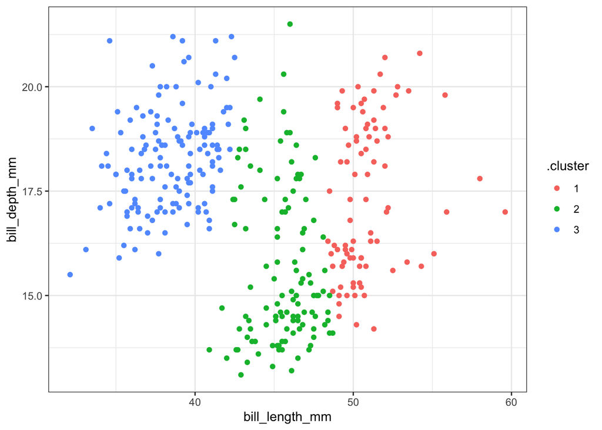

```r
new_clusters %>%
  ggplot(aes(bill_length_mm, bill_depth_mm, color = .cluster)) +
  geom_point() +
  theme_bw()
```

Fix the x- and y-axes and enlarge the data points of cluster means.

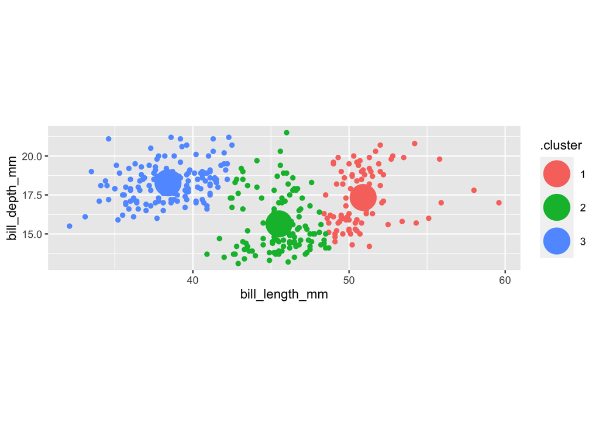

```r
new_clusters %>%
  ggplot(aes(bill_length_mm, bill_depth_mm, color = .cluster)) +
  geom_point() +
  geom_point(aes(color = cluster), size = 10, data = tidy(pen2_kmeans)) +
  coord_fixed()
```

Add a `species` variable to legend.

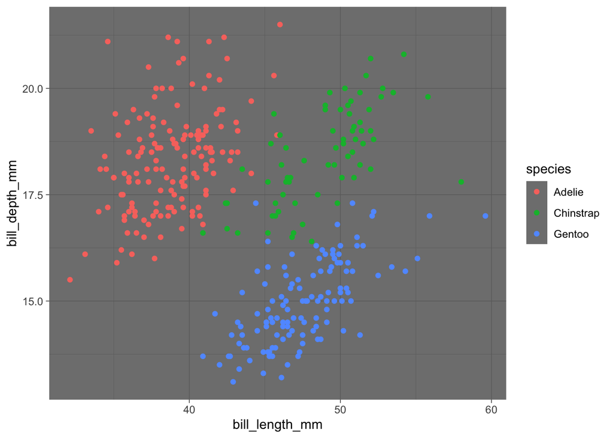

```r
new_clusters %>%
  ggplot(aes(bill_length_mm, bill_depth_mm, color = species)) +
  geom_point() +
  theme_dark()
```

Count species vs cluster sampling

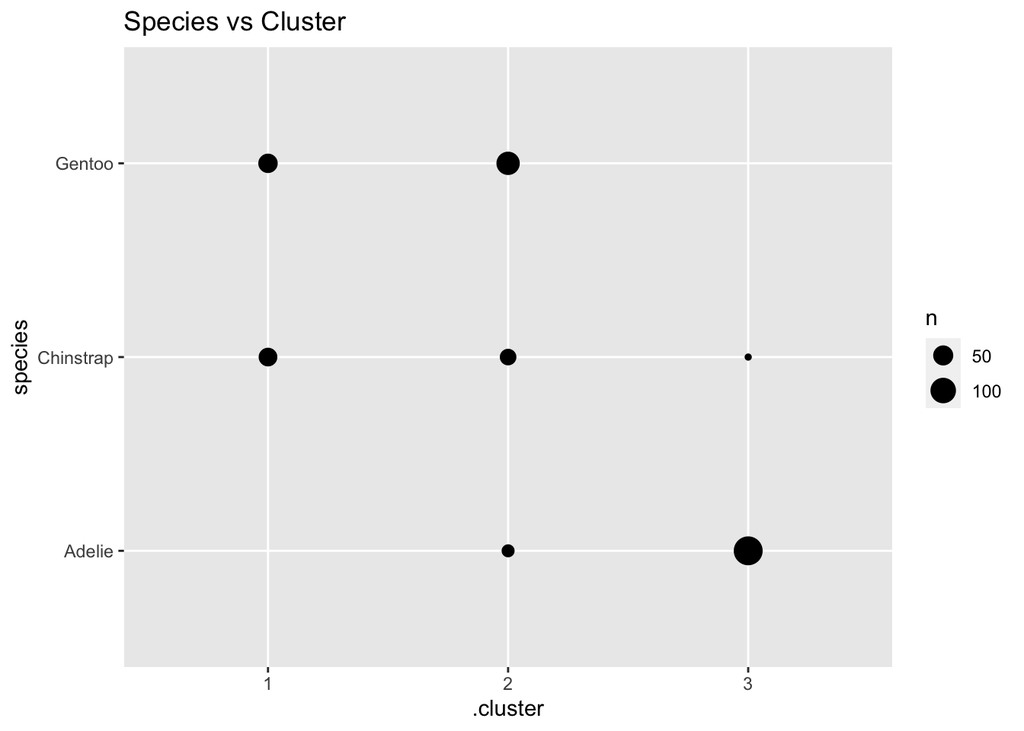

```r
new_clusters %>%
  count(.cluster, species) %>%
  ggplot(aes(.cluster, species, size = n)) +
  geom_point() +
  ggtitle("Species vs Cluster")
```

# 5 Clusters

6. Return The previous steps with more variables and different values of $K$

**Perform k-means using 5 clusters**: We now add two more variables `flipper_length_mm` and `body_mass_g` to the matrix, and save it as `pen3`.

```r
pen3 <- penguins %>%
  select(bill_length_mm, bill_depth_mm, flipper_length_mm, body_mass_g) %>%
  drop_na() %>%
  scale() %>% # will calculate the mean and standard deviation of the entire vector
  as.matrix()
head(pen3)
```

```
##      bill_length_mm bill_depth_mm flipper_length_mm body_mass_g
## [1,]     -0.8832047     0.7843001        -1.4162715  -0.5633167
## [2,]     -0.8099390     0.1260033        -1.0606961  -0.5009690
## [3,]     -0.6634077     0.4298326        -0.4206603  -1.1867934
## [4,]     -1.3227986     1.0881294        -0.5628905  -0.9374027
## [5,]     -0.8465718     1.7464261        -0.7762357  -0.6880121
## [6,]     -0.9198375     0.3285561        -1.4162715  -0.7191859
```

```r
set.seed(1)
pen3_kmeans <- kmeans(pen3, centers = 5) # perform k-means clustering on a data matrix
pen3_kmeans
```

```
## K-means clustering with 5 clusters of sizes 65, 57, 61, 93, 66
##
## Cluster means:
##   bill_length_mm bill_depth_mm flipper_length_mm body_mass_g
## 1      0.9698529     0.7024999        -0.2904650  -0.5278265
## 2      1.0753664    -0.7153018         1.4932089   1.6434628
## 3     -0.6519975     1.1113731        -0.5115943  -0.1069522
## 4     -1.1181668     0.2327247        -0.9918750  -1.0027672
## 5      0.2943188    -1.4292037         0.8669538   0.6123148
##
## Clustering vector:
##   [1] 4 4 4 4 3 4 3 4 3 4 4 4 3 3 4 3 3 4 3 4 4 3 4 4 4 4 4 4 3 4 4 4 3 4 3 3 4
##  [38] 4 3 4 3 4 3 4 3 4 4 4 3 4 3 4 3 4 3 4 3 4 3 4 3 4 3 4 3 4 3 4 3 4 3 4 1 4
##  [75] 3 4 3 4 3 4 3 4 3 4 3 3 4 3 4 4 3 4 3 4 3 4 3 4 3 4 3 4 3 4 4 4 3 4 3 4 3
## [112] 4 3 3 3 4 3 4 4 4 3 4 3 4 3 4 3 4 1 4 3 4 3 4 4 4 3 4 3 4 4 4 4 4 4 3 4 4
## [149] 4 4 3 5 2 5 2 2 5 5 2 5 5 5 2 5 2 5 2 5 2 5 2 2 5 5 5 5 5 5 2 5 2 2 5 5 2
## [186] 2 2 5 2 5 2 5 2 5 5 2 5 5 2 5 2 5 2 5 2 5 5 5 5 5 2 5 2 5 2 5 2 5 2 5 2 5
## [223] 2 2 5 5 2 5 2 5 2 5 2 5 2 5 2 5 2 5 2 5 2 5 2 5 2 2 5 5 2 5 2 5 2 5 2 5 2
## [260] 5 2 2 2 5 2 5 2 5 2 5 5 2 5 2 1 1 1 1 1 1 1 1 1 1 1 1 1 1 1 1 1 1 1 1 4 1
## [297] 4 1 1 1 1 1 1 1 4 1 4 1 1 1 1 1 1 1 1 1 1 1 1 1 1 1 1 1 1 1 1 1 4 1 1 1 1
## [334] 1 1 1 1 1 1 1 1 1
##
## Within cluster sum of squares by cluster:
## [1] 66.25997 37.34371 43.15683 58.11216 27.04454
##  (between_SS / total_SS =  83.0 %)
##
## Available components:
##
## [1] "cluster"      "centers"      "totss"        "withinss"     "tot.withinss"
## [6] "betweenss"    "size"         "iter"         "ifault"
```

Result of 5 Clusters with 4 variables.

```r
tidy(pen3_kmeans)
```

```
## # A tibble: 5 x 7
##   bill_length_mm bill_depth_mm flipper_length_mm body_mass_g  size withinss
##            <dbl>         <dbl>             <dbl>       <dbl> <int>    <dbl>
## 1          0.970         0.702            -0.290      -0.528    65     66.3
## 2          1.08         -0.715             1.49        1.64     57     37.3
## 3         -0.652         1.11             -0.512      -0.107    61     43.2
## 4         -1.12          0.233            -0.992      -1.00     93     58.1
## 5          0.294        -1.43              0.867       0.612    66     27.0
## # … with 1 more variable: cluster <fct>
```

Data visualzation

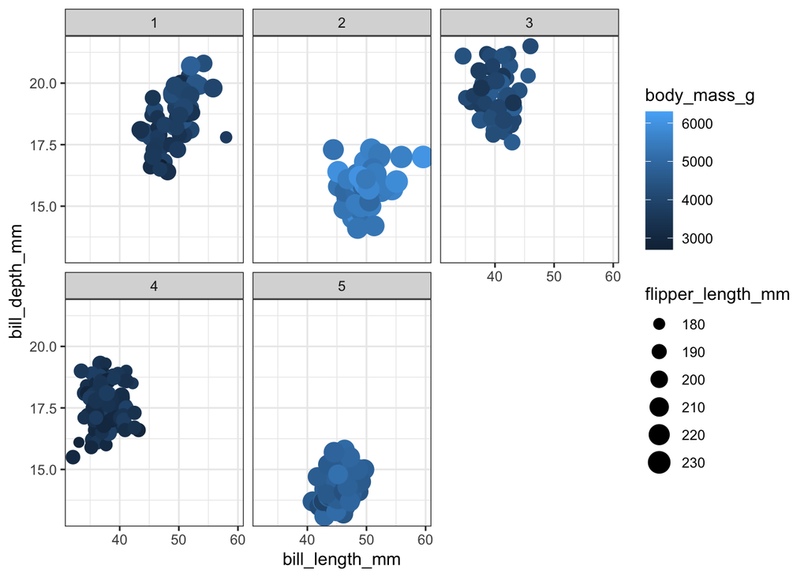

```r
penguins %>%
  select(species:body_mass_g) %>%
  drop_na() -> tmp
augment(pen3_kmeans, tmp) %>%
  ggplot(aes(bill_length_mm, bill_depth_mm, color = body_mass_g, size = flipper_length_mm)) +
  geom_point() +
  theme_bw() +
  facet_wrap(~.cluster)
```

# Elbow Chart

7. Construct an Elbow Chart to find an appropriate number of clusters for the data set
- We need to visualize the total within-cluster sum of squares with each k
- According to the Elbow Chart, we can say the roughly appropriate number of clusters is k = 2.

```r
tibble(k = 1:10) %>%
  mutate(models = map(k, ~kmeans(pen3, centers = .x))) %>% #.x = k %>%
  mutate(tot.withinss = map_dbl(models, "tot.withinss")) -> many_kmenas_res
```

Plotting

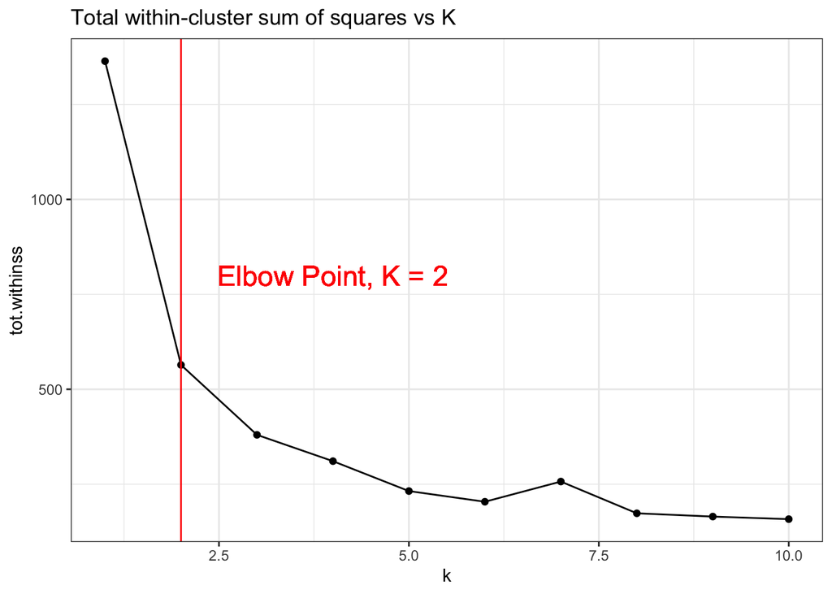

```r
many_kmenas_res %>%
  ggplot(aes(k, tot.withinss)) +
  geom_point() +
  geom_line() +
  theme_bw() +
  ggtitle("Total within-cluster sum of squares vs K") +
  geom_vline(xintercept = 2, color = "red") +
  geom_text(x = 4, y = 800, label = "Elbow Point, K = 2",
            size = 6, colour = "red")
```

# References

- https://en.wikipedia.org/wiki/K-means_clustering
- https://www.rdocumentation.org/packages/stats/versions/3.6.2/topics/kmeans
- https://stackoverflow.com/questions/20256028/understanding-scale-in-r